# Cross Validation Problem Set

Your Name Here

# 1 Introduction

This problem set corresponds to the chapter on model selection in the course https://doe.dscoe.org. For this problem set, we will use the following packages:

```r
library(tidyverse)
library(bestglm)
library(glmnet)
```

As with the previous problem set , we will use the `SAheart` dataset from the `bestglm` package. As a reminder, from the help documentation, we find that the data consists of 462 observations of 10 variables. The response is `chd`, which is a binary variable indicating the presence (1) or absence (0) of coronary heart disease.

# 2 Train and Test Sets

Create training and test sets using an 80/20 split.

```r
set.seed(0)
test_idx = sample(462, 92, replace=FALSE)

train_set = SAheart[-test_idx, ]
test_set = SAheart[test_idx, ]
```

# 3 AIC Model

Find the best model using AIC (remember that the response is binary). This should be the same model fit in the previous problem set.

```r
sa.glm = bestglm(train_set, IC="AIC", family=binomial)
```

```
## Morgan-Tatar search since family is non-gaussian.
```

```r
sa.glm$BestModel
```

```
##
## Call:  glm(formula = y ~ ., family = family, data = Xi, weights = weights)
##
## Coefficients:
##    (Intercept)         tobacco             ldl  famhistPresent           typea
##       -6.43502         0.09119         0.14782         1.10670         0.03716
##            age
##        0.04826
##
## Degrees of Freedom: 369 Total (i.e. Null);  364 Residual
## Null Deviance:       479.7
## Residual Deviance: 383   AIC: 395
```

# 4 `bestglm` Model

Find the best model using The “HTF” method with your choice for the number folds and replications. For reproducibility, choose a seed number before performing cross validation.

```r
set.seed(0)
sa.cv = bestglm(train_set, IC="CV", CVArgs=list(Method="HTF",K=10,REP=2), family=binomial)
```

```
## Morgan-Tatar search since family is non-gaussian.
```

```r
sa.cv
```

```
## CV(K = 10, REP = 2)
## BICq equivalent for q in (0.0731236516282316, 0.212549161037243)
## Best Model:
##                   Estimate Std. Error   z value     Pr(>|z|)
## (Intercept)    -3.61765266 0.51069164 -7.083830 1.402241e-12
## tobacco         0.09219927 0.02930478  3.146220 1.653957e-03
## famhistPresent  1.16369531 0.24525759  4.744788 2.087247e-06
## age             0.04603903 0.01058299  4.350285 1.359607e-05
```

## 4.1 Predictors

Plot the number of predictors on the x-axis and the CV prediction error and the standard error on the y-axis. How many predictors are included in the model with the lowest CV error versus the best model?

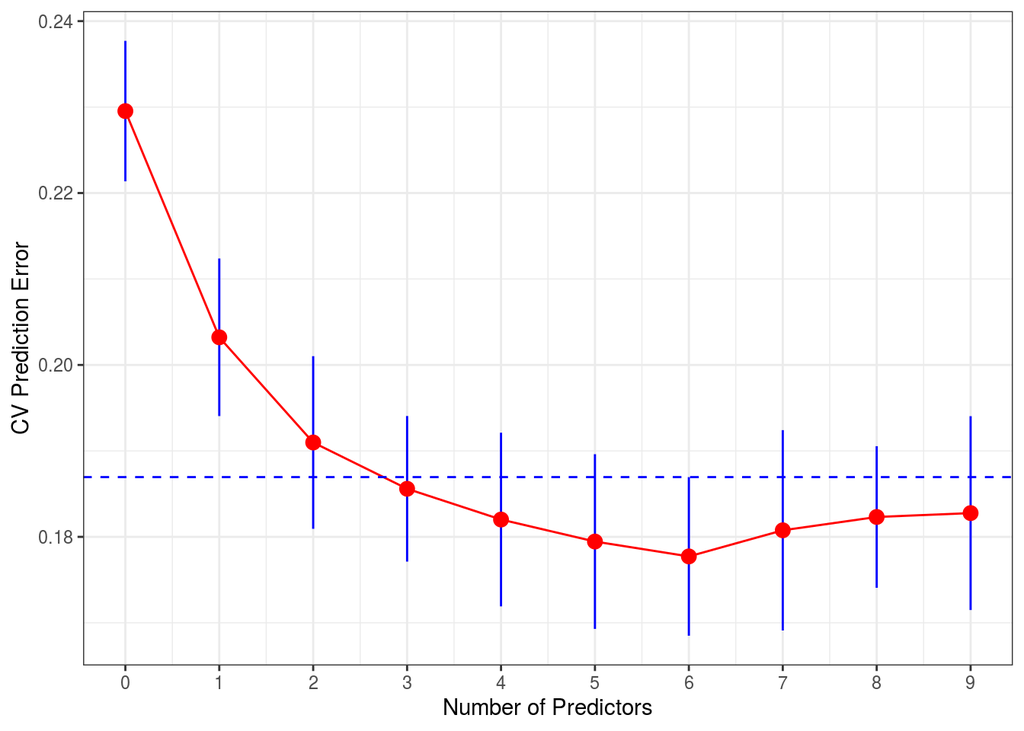

```r
sa.df = tibble(
  cv = sa.cv$Subsets$CV,    # cross validation errors
  se = sa.cv$Subsets$sdCV,  # standard errors
  cv.low = cv - se,
  cv.high= cv + se,
  p = 0:(length(cv)-1)      # number of predictors
)

ggplot(sa.df) +
  geom_segment(aes(x=0:9, xend=0:9, y=cv.low, yend=cv.high), color='blue') +
  geom_line(aes(x=p, y=cv), color='red') +
  geom_point(aes(x=p, y=cv), color='red', size=3) +
  geom_hline(yintercept = sa.df %>% filter(p==6) %>% .$cv.high, color='blue', linetype=2) +
  scale_x_continuous(breaks = 0:9) +
  xlab("Number of Predictors") +
  ylab("CV Prediction Error") +
  theme_bw()
```